# Assessmnet-1 Part-1

Ryosuke Otsuka s4663911

2022-03-20

1. Setup your Assessment 1 project:

2 Create the heading of the first level and call it RMarkdown editing

# RMarkdown editing

3. Write 2-3 sentences about RMarkdown (you can google this information or use resources recommended in class - no need to reference)
4. In the above use bold and italics for editing.

**R Markdown** provides an *unified authoring framework for the data science, integrating your code, its results.* R Markdown doccuments are fully repeatable and support multiple formats, **such as PDFs**, **Word files.**

5. Review the suggested documentation on how to insert links in the .rmd file and include an in-text link to https://rmarkdown.rstudio.com/lesson-8.html

[here](https://rmarkdown.rstudio.com/lesson-8.html)

6. Insert an R chunk and create a variable with this dataset

```r
fastfood <- read.csv("https://raw.githubusercontent.com/rfordatascience/tidytuesday/master/data/2018/2018-09-04/fastfood_calories.csv")
```

7. Display the first 10 rows of the dataset using head() and kable(). Display the first 10 rows of the dataset and the first 5 variables

```r
library(tidyverse)
library(knitr)

head(fastfood, 10)
```

```
##     X restaurant                                      item calories cal_fat
## 1   1  Mcdonalds          Artisan Grilled Chicken Sandwich      380      60
## 2   2  Mcdonalds            Single Bacon Smokehouse Burger      840     410
## 3   3  Mcdonalds            Double Bacon Smokehouse Burger     1130     600
## 4   4  Mcdonalds Grilled Bacon Smokehouse Chicken Sandwich      750     280
## 5   5  Mcdonalds  Crispy Bacon Smokehouse Chicken Sandwich      920     410
## 6   6  Mcdonalds                                   Big Mac      540     250
## 7   7  Mcdonalds                              Cheeseburger      300     100
## 8   8  Mcdonalds                  Classic Chicken Sandwich      510     210
## 9   9  Mcdonalds                       Double Cheeseburger      430     190
## 10 10  Mcdonalds      Double Quarter PounderÂ® with Cheese      770     400
##    total_fat sat_fat trans_fat cholesterol sodium total_carb fiber sugar
## 1          7       2       0.0          95   1110         44     3    11
## 2         45      17       1.5         130   1580         62     2    18
## 3         67      27       3.0         220   1920         63     3    18
```

[output cut: 18 more lines]

```r
kable(head(fastfood[, 1:5]), "pipe")
```

| X | restaurant | item | calories | cal_fat |
| --- | --- | --- | --- | --- |
| 1 | Mcdonalds | Artisan Grilled Chicken Sandwich | 380 | 60 |
| 2 | Mcdonalds | Single Bacon Smokehouse Burger | 840 | 410 |
| 3 | Mcdonalds | Double Bacon Smokehouse Burger | 1130 | 600 |
| 4 | Mcdonalds | Grilled Bacon Smokehouse Chicken Sandwich | 750 | 280 |
| 5 | Mcdonalds | Crispy Bacon Smokehouse Chicken Sandwich | 920 | 410 |
| 6 | Mcdonalds | Big Mac | 540 | 250 |

## Part_2

8. Display the observations that has more than 1000 calories

```r
fastfood %>%
  filter(calories > 1000) %>%
  head(n = 30)
```

```
##      X  restaurant                                             item calories
## 1    3   Mcdonalds                   Double Bacon Smokehouse Burger     1130
## 2   38   Mcdonalds       10 piece Buttermilk Crispy Chicken Tenders     1210
## 3   39   Mcdonalds       12 piece Buttermilk Crispy Chicken Tenders     1510
## 4   40   Mcdonalds       20 piece Buttermilk Crispy Chicken Tenders     2430
## 5   45   Mcdonalds                       40 piece Chicken McNuggets     1770
## 6   48   Mcdonalds 10 piece Sweet N' Spicy Honey BBQ Glazed Tenders     1600
## 7   99       Sonic   Super Sonic Bacon Double Cheeseburger (w/mayo)     1280
## 8  100       Sonic       Super Sonic Double Cheeseburger W/ Mustard     1120
## 9  101       Sonic       Super Sonic Double Cheeseburger W/ Ketchup     1130
## 10 102       Sonic          Super Sonic Double Cheeseburger W/ Mayo     1220
## 11 103       Sonic         Super Sonic Jalapeno Double Cheeseburger     1120
## 12 116       Sonic Garlic Parmesan Dunked Ultimate Chicken Sandwich     1350
## 13 122       Sonic        4 Piece Super Crunch Chicken Strip Dinner     1080
## 14 123       Sonic        5 Piece Super Crunch Chicken Strip Dinner     1190
```

[output cut: 72 more lines]

9. Arrange observations with more than 40 in total_fat and more than 80 in total_carb in the descending order (PLEASE USE THE VARIABLE OF YOUR CHOICE TO ORGANISE THE DESCENDING ORDER) and save them to a new variable (dataset) called `dont_eat_this`

```r
dont_eat_this <- fastfood %>%
  filter(total_fat > 40, total_carb > 80) %>%
  arrange(total_fat, total_carb = TRUE)
```

10. Using the initial dataset variable, use `case_when()` to create a new variable `heavy_food` which is equal to “heavy” when total calories are greater than 500, “low” when total calories are less than 250 and “average” for all other cases. Count the number of observations in each created category.

```r
fastfood <- fastfood %>%
  mutate(heavy_food = case_when(calories > 500 ~ "heavy",calories < 250 ~ "low",TRUE ~ "avarage"))

fastfood %>%
count(heavy_food, sort = TRUE, name = "Calories category")
```

```
##   heavy_food Calories category
## 1      heavy               246
## 2    avarage               201
## 3        low                68
```

11. Display the types of variables in the dataset using `skimr` package

```r
library(skimr)

skim(fastfood)
```

Data summary

| Name | fastfood |
| --- | --- |
| Number of rows | 515 |
| Number of columns | 19 |
| _______________________ |  |
| Column type frequency: |  |
| character | 4 |
| numeric | 15 |
| ________________________ |  |
| Group variables | None |

**Variable type: character**

| skim_variable | n_missing | complete_rate | min | max | empty | n_unique | whitespace |
| --- | --- | --- | --- | --- | --- | --- | --- |
| restaurant | 0 | 1 | 5 | 11 | 0 | 8 | 0 |
| item | 0 | 1 | 5 | 63 | 0 | 505 | 0 |
| salad | 0 | 1 | 5 | 5 | 0 | 1 | 0 |
| heavy_food | 0 | 1 | 3 | 7 | 0 | 3 | 0 |

**Variable type: numeric**

| skim_variable | n_missing | complete_rate | mean | sd | p0 | p25 | p50 | p75 | p100 | hist |
| --- | --- | --- | --- | --- | --- | --- | --- | --- | --- | --- |
| X | 0 | 1.00 | 258.00 | 148.81 | 1 | 129.5 | 258.0 | 386.5 | 515 | ▇▇▇▇▇ |
| calories | 0 | 1.00 | 530.91 | 282.44 | 20 | 330.0 | 490.0 | 690.0 | 2430 | ▇▆▁▁▁ |
| cal_fat | 0 | 1.00 | 238.81 | 166.41 | 0 | 120.0 | 210.0 | 310.0 | 1270 | ▇▃▁▁▁ |
| total_fat | 0 | 1.00 | 26.59 | 18.41 | 0 | 14.0 | 23.0 | 35.0 | 141 | ▇▃▁▁▁ |
| sat_fat | 0 | 1.00 | 8.15 | 6.42 | 0 | 4.0 | 7.0 | 11.0 | 47 | ▇▃▁▁▁ |
| trans_fat | 0 | 1.00 | 0.47 | 0.84 | 0 | 0.0 | 0.0 | 1.0 | 8 | ▇▁▁▁▁ |
| cholesterol | 0 | 1.00 | 72.46 | 63.16 | 0 | 35.0 | 60.0 | 95.0 | 805 | ▇▁▁▁▁ |
| sodium | 0 | 1.00 | 1246.74 | 689.95 | 15 | 800.0 | 1110.0 | 1550.0 | 6080 | ▇▆▁▁▁ |
| total_carb | 0 | 1.00 | 45.66 | 24.88 | 0 | 28.5 | 44.0 | 57.0 | 156 | ▅▇▂▁▁ |
| fiber | 12 | 0.98 | 4.14 | 3.04 | 0 | 2.0 | 3.0 | 5.0 | 17 | ▇▅▂▁▁ |
| sugar | 0 | 1.00 | 7.26 | 6.76 | 0 | 3.0 | 6.0 | 9.0 | 87 | ▇▁▁▁▁ |
| protein | 1 | 1.00 | 27.89 | 17.68 | 1 | 16.0 | 24.5 | 36.0 | 186 | ▇▂▁▁▁ |
| vit_a | 214 | 0.58 | 18.86 | 31.38 | 0 | 4.0 | 10.0 | 20.0 | 180 | ▇▁▁▁▁ |
| vit_c | 210 | 0.59 | 20.17 | 30.59 | 0 | 4.0 | 10.0 | 30.0 | 400 | ▇▁▁▁▁ |
| calcium | 210 | 0.59 | 24.85 | 25.52 | 0 | 8.0 | 20.0 | 30.0 | 290 | ▇▁▁▁▁ |

12. Present the count observations from each restaurant in a descending order

```r
fastfood %>%
  count(restaurant, sort = TRUE)
```

```
##    restaurant   n
## 1   Taco Bell 115
## 2      Subway  96
## 3 Burger King  70
## 4   Mcdonalds  57
## 5       Arbys  55
## 6       Sonic  53
## 7 Dairy Queen  42
## 8 Chick Fil-A  27
```

13. Using groupings (group_by()), summarise and display the average number of calories for each restaurant.

```r
fastfood %>%
  group_by(restaurant) %>%
  summarise(mean(calories)) %>%
  ungroup()
```

```
## # A tibble: 8 x 2
##   restaurant  `mean(calories)`
##   <chr>                  <dbl>
## 1 Arbys                   533.
## 2 Burger King             609.
## 3 Chick Fil-A             384.
## 4 Dairy Queen             520.
## 5 Mcdonalds               640.
## 6 Sonic                   632.
## 7 Subway                  503.
## 8 Taco Bell               444.
```

14. Add variables to the dataset, which:
- calculates the average calories per type of restaurant and call it `average_calories`
- calculates the maximum total_fat per type of restaurant and call it `max_fat`
- calculates the minimum cholesterol per type of restaurant and call it `min_cholesterol`

```r
fastfood <- fastfood %>%
  group_by(restaurant) %>%
  mutate("avarege_calories" = mean(calories)) %>%
  ungroup()
```

```r
fastfood <- fastfood %>%
  group_by(restaurant) %>%
  mutate("max_fat" = max(total_fat)) %>%
  ungroup()
```

```r
fastfood <- fastfood %>%
  group_by(restaurant) %>%
  mutate("min_cholesterol" = min(cholesterol)) %>%
  ungroup()
```

15. Display the data vis of total fat per each type of restaurant. Write a narration (2-3 sentences) why you believe this type of data viz presents such information best.

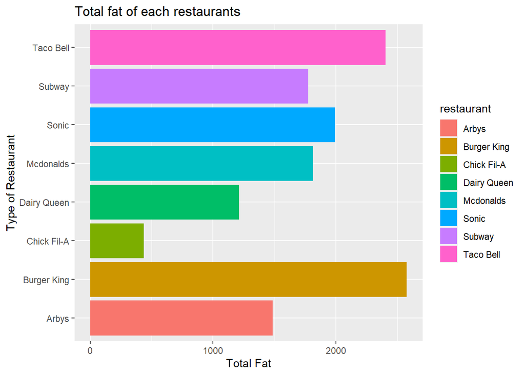

```r
fastfood %>%
  ggplot(aes(restaurant, total_fat, fill = restaurant)) +
  geom_col() +
  coord_flip() +
  labs(x = "Type of Restaurant", y = "Total Fat", fill =
         "restaurant",title = "Total fat of each restaurants")
```

Type of restaurant is categorised as a discrete valuable, whereas total fat is a continuous valuable. In this case, geom_col is the most suitable data visualisation in order compare the total fat with each type of restaurant.

16. Add a variable to the dataset, which calculates the sum of cholesterol and sodium and call it `cholesterol_sodium`. Remove the variable `salad`

```r
fastfood <- fastfood %>%
  mutate(cholesterol_sodium = cholesterol + sodium, "salad" = NULL)
```

17. Use observations for Mcdonalds to plot sugar variable against protein with `geom_point()`

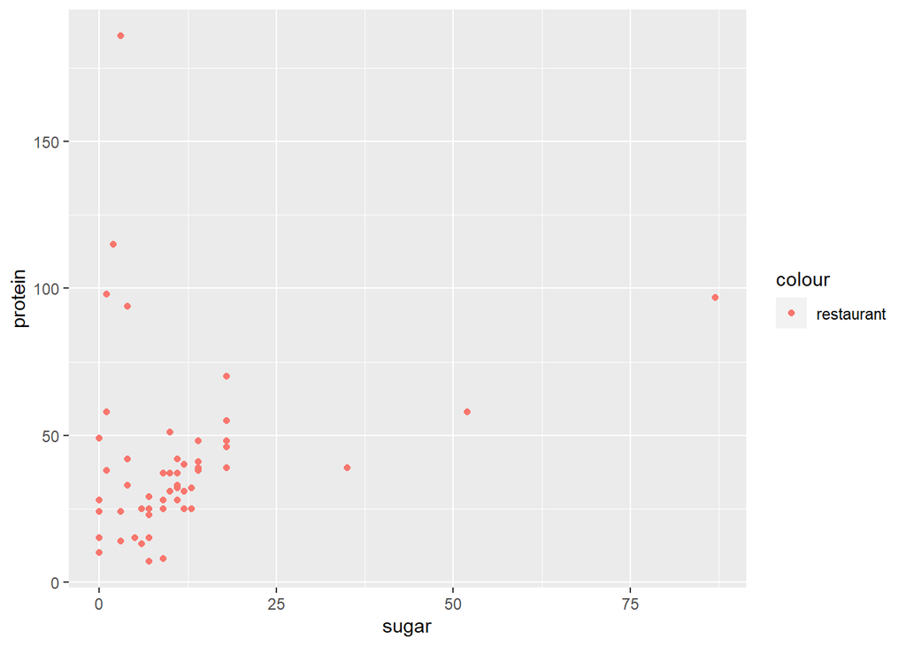

```r
fastfood %>%
  filter(restaurant == "Mcdonalds") %>%
  ggplot(aes(sugar, protein, col = "restaurant")) + geom_point()
```

18. Identify variable(s) which should be factors and transform their type into a factor variable.

```r
as_factor(fastfood$restaurant) %>%
  head(n=20)
```

```
##  [1] Mcdonalds Mcdonalds Mcdonalds Mcdonalds Mcdonalds Mcdonalds Mcdonalds
##  [8] Mcdonalds Mcdonalds Mcdonalds Mcdonalds Mcdonalds Mcdonalds Mcdonalds
## [15] Mcdonalds Mcdonalds Mcdonalds Mcdonalds Mcdonalds Mcdonalds
## 8 Levels: Mcdonalds Chick Fil-A Sonic Arbys Burger King Dairy Queen ... Taco Bell
```

```r
as_factor(fastfood$item) %>%
  head(n=20)
```

```
##  [1] Artisan Grilled Chicken Sandwich
##  [2] Single Bacon Smokehouse Burger
##  [3] Double Bacon Smokehouse Burger
##  [4] Grilled Bacon Smokehouse Chicken Sandwich
##  [5] Crispy Bacon Smokehouse Chicken Sandwich
##  [6] Big Mac
##  [7] Cheeseburger
##  [8] Classic Chicken Sandwich
##  [9] Double Cheeseburger
## [10] Double Quarter PounderÂ® with Cheese
## [11] Filet-O-FishÂ®
## [12] Garlic White Cheddar Burger
## [13] Grilled Garlic White Cheddar Chicken Sandwich
## [14] Crispy Garlic White Cheddar Chicken Sandwich
## [15] Hamburger
## [16] Lobster Roll
## [17] Maple Bacon Dijon 1/4 lb Burger
## [18] Grilled Maple Bacon Dijon Chicken Sandwich
## [19] Crispy Maple Bacon Dijon Chicken Sandwich
## [20] McChicken
## 505 Levels: Artisan Grilled Chicken Sandwich ... Fiesta Taco Salad-Steak
```

```r
skim(fastfood)
```

Data summary

| Name | fastfood |
| --- | --- |
| Number of rows | 515 |
| Number of columns | 22 |
| _______________________ |  |
| Column type frequency: |  |
| character | 3 |
| numeric | 19 |
| ________________________ |  |
| Group variables | None |

**Variable type: character**

| skim_variable | n_missing | complete_rate | min | max | empty | n_unique | whitespace |
| --- | --- | --- | --- | --- | --- | --- | --- |
| restaurant | 0 | 1 | 5 | 11 | 0 | 8 | 0 |
| item | 0 | 1 | 5 | 63 | 0 | 505 | 0 |
| heavy_food | 0 | 1 | 3 | 7 | 0 | 3 | 0 |

**Variable type: numeric**

| skim_variable | n_missing | complete_rate | mean | sd | p0 | p25 | p50 | p75 | p100 | hist |
| --- | --- | --- | --- | --- | --- | --- | --- | --- | --- | --- |
| X | 0 | 1.00 | 258.00 | 148.81 | 1.00 | 129.50 | 258.00 | 386.50 | 515.00 | ▇▇▇▇▇ |
| calories | 0 | 1.00 | 530.91 | 282.44 | 20.00 | 330.00 | 490.00 | 690.00 | 2430.00 | ▇▆▁▁▁ |
| cal_fat | 0 | 1.00 | 238.81 | 166.41 | 0.00 | 120.00 | 210.00 | 310.00 | 1270.00 | ▇▃▁▁▁ |
| total_fat | 0 | 1.00 | 26.59 | 18.41 | 0.00 | 14.00 | 23.00 | 35.00 | 141.00 | ▇▃▁▁▁ |
| sat_fat | 0 | 1.00 | 8.15 | 6.42 | 0.00 | 4.00 | 7.00 | 11.00 | 47.00 | ▇▃▁▁▁ |
| trans_fat | 0 | 1.00 | 0.47 | 0.84 | 0.00 | 0.00 | 0.00 | 1.00 | 8.00 | ▇▁▁▁▁ |
| cholesterol | 0 | 1.00 | 72.46 | 63.16 | 0.00 | 35.00 | 60.00 | 95.00 | 805.00 | ▇▁▁▁▁ |
| sodium | 0 | 1.00 | 1246.74 | 689.95 | 15.00 | 800.00 | 1110.00 | 1550.00 | 6080.00 | ▇▆▁▁▁ |
| total_carb | 0 | 1.00 | 45.66 | 24.88 | 0.00 | 28.50 | 44.00 | 57.00 | 156.00 | ▅▇▂▁▁ |
| fiber | 12 | 0.98 | 4.14 | 3.04 | 0.00 | 2.00 | 3.00 | 5.00 | 17.00 | ▇▅▂▁▁ |
| sugar | 0 | 1.00 | 7.26 | 6.76 | 0.00 | 3.00 | 6.00 | 9.00 | 87.00 | ▇▁▁▁▁ |
| protein | 1 | 1.00 | 27.89 | 17.68 | 1.00 | 16.00 | 24.50 | 36.00 | 186.00 | ▇▂▁▁▁ |
| vit_a | 214 | 0.58 | 18.86 | 31.38 | 0.00 | 4.00 | 10.00 | 20.00 | 180.00 | ▇▁▁▁▁ |
| vit_c | 210 | 0.59 | 20.17 | 30.59 | 0.00 | 4.00 | 10.00 | 30.00 | 400.00 | ▇▁▁▁▁ |
| calcium | 210 | 0.59 | 24.85 | 25.52 | 0.00 | 8.00 | 20.00 | 30.00 | 290.00 | ▇▁▁▁▁ |
| avarege_calories | 0 | 1.00 | 530.91 | 78.63 | 384.44 | 443.65 | 520.24 | 608.57 | 640.35 | ▁▅▇▁▇ |
| max_fat | 0 | 1.00 | 78.84 | 35.08 | 42.00 | 47.00 | 62.00 | 100.00 | 141.00 | ▇▆▂▁▅ |
| min_cholesterol | 0 | 1.00 | 3.59 | 6.88 | 0.00 | 0.00 | 0.00 | 5.00 | 25.00 | ▇▁▁▁▁ |
| cholesterol_sodium | 0 | 1.00 | 1319.19 | 729.37 | 15.00 | 850.00 | 1180.00 | 1662.50 | 6555.00 | ▇▅▁▁▁ |

19. Create two new variables: Read about `cut_number()` function using Help and add a new variable to the dataset `calories_type`. Use `calories` variable for `cut_number()` function to split it into 3 categories `n=3`, add labels `labels=c("low", "med", "high")` and make the dataset ordered by arranging it according to calories.

```r
fastfood %>%
  mutate(calories_type = cut_number(calories, n = 3, labels=c("low", "med", "high"))) %>%
  arrange(desc(calories))
```

```
## # A tibble: 515 x 23
##        X restaurant  item           calories cal_fat total_fat sat_fat trans_fat
##    <int> <chr>       <chr>             <int>   <int>     <int>   <dbl>     <dbl>
##  1    40 Mcdonalds   20 piece Butt~     2430    1270       141      24       2
##  2    45 Mcdonalds   40 piece Chic~     1770     960       107      18       0.5
##  3    48 Mcdonalds   10 piece Swee~     1600     600        66      10       0
##  4   193 Burger King American Brew~     1550    1134       126      47       8
##  5    39 Mcdonalds   12 piece Butt~     1510     790        88      15       1
##  6   116 Sonic       Garlic Parmes~     1350     900       100      17       0
##  7    99 Sonic       Super Sonic B~     1280     830        92      36       4
##  8   271 Dairy Queen 6 Piece Chick~     1260     590        66      11       1
##  9   212 Burger King Rodeo King         1250     738        82      31       3.5
## 10   102 Sonic       Super Sonic D~     1220     780        87      34       4
## # ... with 505 more rows, and 15 more variables: cholesterol <int>,
## #   sodium <int>, total_carb <int>, fiber <int>, sugar <int>, protein <int>,
## #   vit_a <int>, vit_c <int>, calcium <int>, heavy_food <chr>,
## #   avarege_calories <dbl>, max_fat <int>, min_cholesterol <int>,
## #   cholesterol_sodium <int>, calories_type <fct>
```

20. Create a dataviz that shows the distribution of `calories_type` in food items for each type of restaurant. Think carefully about the choice of data viz. Use facets, coordinates and theme layers to make your data viz visually appealing and meaningful. Use factors related data viz functions.

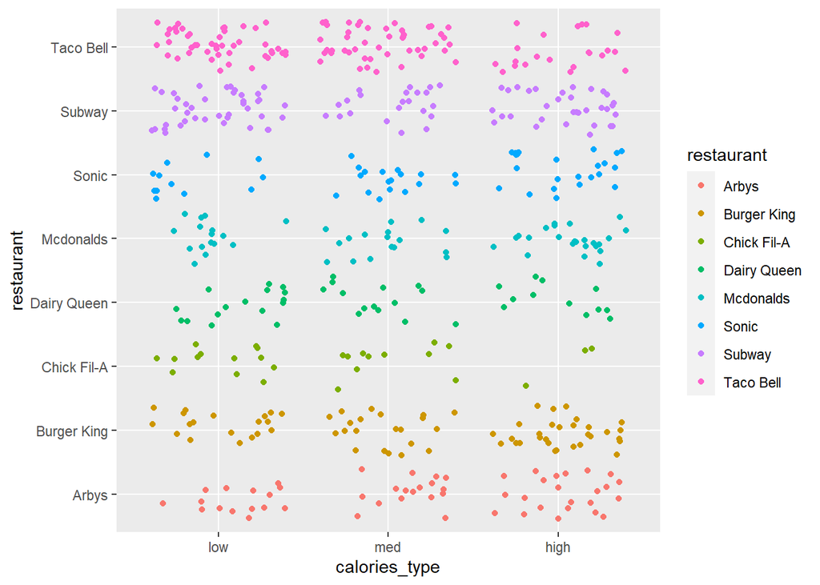

```r
library(ggplot2)

calories_types <- fastfood %>%
  mutate(calories_type = cut_number(calories, n = 3,labels=c("low", "med", "high")))

calories_types %>%
  ggplot(aes(restaurant, calories_type, col = restaurant)) +
  geom_jitter() +
  coord_flip()
```

21. The second variable should show the percentage of `trans_fat` in `total_fat`. Add the variable to the dataset and call it `trans_fat_percent`. Do not forget to save the updated dataset.

```r
fastfood <- fastfood %>%
  mutate(trans_fat_persent = trans_fat / total_fat * 100)
```

22. Create a dataviz that shows the distribution of `trans_fat` in food items for each type of restaurant. Think carefully about the choice of data viz. Use facets, coordinates and theme layers to make your data viz visually appealing and meaningful.

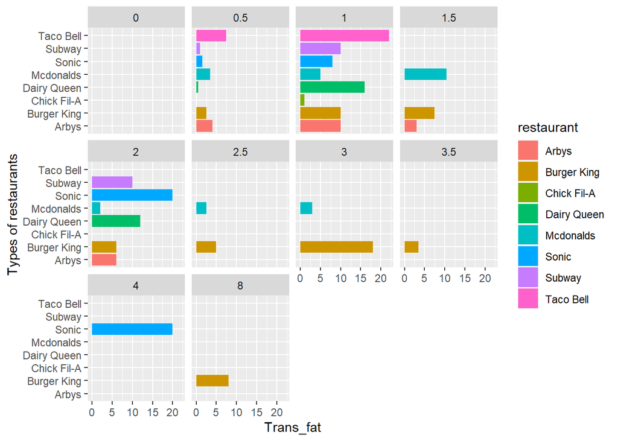

```r
fastfood %>%
  ggplot(aes(restaurant, trans_fat, fill = restaurant)) +
  geom_col() +
  facet_wrap(~ trans_fat) +
  coord_flip() +
  labs(x = "Types of restaurants", y = "Trans_fat") +
  theme_get()
```

23. Calculate and show the average (mean) `total_fat` for each type of restaurant. No need to save it as a variable.

```r
fastfood %>%
  group_by(restaurant) %>%
  summarise(mean(total_fat))
```

```
## # A tibble: 8 x 2
##   restaurant  `mean(total_fat)`
##   <chr>                   <dbl>
## 1 Arbys                    27.0
## 2 Burger King              36.8
## 3 Chick Fil-A              16.1
## 4 Dairy Queen              28.9
## 5 Mcdonalds                31.8
## 6 Sonic                    37.6
## 7 Subway                   18.5
## 8 Taco Bell                20.9
```

24. And create a dataviz that allow to compare different restaurants on this variable (`total_fat`). You can present it on one dataviz (= no facets). Think carefully about the choice of data viz. Use coordinates and theme layers to make your data viz visually appealing and meaningful.

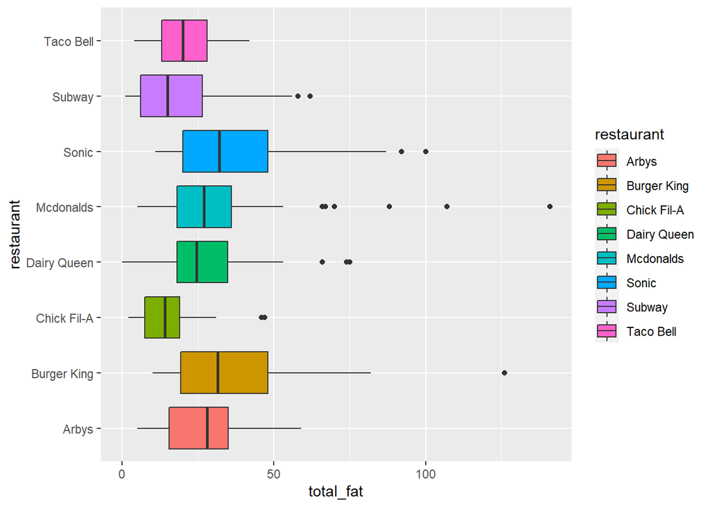

```r
fastfood %>%
  group_by(restaurant) %>%
  mutate("average_fat" = mean(total_fat)) -> average_fat

average_fat %>%
  ggplot(aes(restaurant, total_fat, fill = restaurant)) +
  geom_boxplot() +
  coord_flip()
```